# *M. cavernosa* transcriptome analysis

Ross Cunning

May 22, 2020

# Setup

```r
knitr::opts_chunk$set(echo = TRUE, warning = FALSE, message = FALSE, cache = TRUE)
```

```r
# Load libraries
library(DESeq2)    # BiocManager::install('DESeq2')
library(limma)     # BiocManager::install('limma')
library(stringr)
library(readxl)
library(pheatmap)
library(RColorBrewer)
library(variancePartition)  # BiocManager::install('variancePartition')
library(doParallel)
library(cowplot)
source("code/GO_MWU/gomwu.functions.R")
library(tidyverse)
library(KOGMWU)  # install.packages("KOGMWU")
library(adegenet)
library(ggpubr)
library(kableExtra)

## ggplot theme
theme_custom <- function() {
  theme_bw(base_size = 10) %+replace%    #, base_family = "Arial"
    theme(
      panel.grid.major = element_blank(),
      panel.grid.minor = element_blank(),
      panel.background = element_blank(),
      panel.border = element_rect(color = "black", fill = NA),
      legend.background = element_rect(fill = NA, colour = NA),
      axis.text.x = element_text(angle=45, hjust=1, vjust = 1)#,
      #legend.title = element_text(size = 8),
      #legend.text = element_text(size = 7)
    )
}
## ggplot labeller
colnames <- c(
  `20` = "genet 1",
  `22` = "genet 2",
  `26` = "genet 3"
)

contrastnames <- c(
  `Dc.Cc` = expression("D"[C]~"vs."~"C"[C]),
  `Dh.Dc` = expression("D"[H]~"vs."~"D"[C]),
  `Ch.Cc` = expression("C"[H]~"vs."~"C"[C])
)

global_labeller <- labeller(
  colony = colnames,
  contrast = contrastnames,
  .default = "label_parsed"
)
```

# Load data

#### Gene count data

```r
# Import gene expression / count data
counts <- read.table("data/tagseq/processed/counts_newpars.txt",
                     header = TRUE, row.names = 1)
# Trim column names to just the sample name
colnames(counts) <- str_sub(colnames(counts), 1, 7)
# Order columns by sample name
counts <- counts[, order(colnames(counts))]
```

#### Sample metadata

```r
# Import sample metadata
sdat0 <- read_xlsx("data/sample_metadata.xlsx") %>%
  mutate(sym = recode(trt1, b = "D", c = "C"),
         sample = paste0(species, colony, ".", core),
         group = paste(sym, trt2, sep = ""),
         colony = factor(colony),
         colony.group = interaction(colony, group)) %>%
  mutate_if(is.character, as.factor)

sdat <- sdat0 %>%
  arrange(sample) %>%                              # order rows by sample name
  column_to_rownames(var = "sample")               # set sample name to rownames
```

#### Gene annotations

```r
trinotate <- readxl::read_xlsx("data/genome/Mcavernosa_trinotate_annotation_report.xlsx",
                                sheet = "Mcavernosa_trinotate_annotation")
```

### Create DESeqDataSet

```r
# Create full DESeqDataSet
dds <- DESeqDataSetFromMatrix(countData = counts,
                              colData = sdat,
                              design = ~ colony)

# Subset DESeqDataSet
## Subset time point at end of heat stress
dds <- dds[, colData(dds)$date_sampled == "2017-10-28"]
### Remove genes counted zero times in subset
dds <- dds[ rowSums(counts(dds)) > 0, ]

## Subset only the colonies in the heat stress experiment
hs.dds <- dds[, colData(dds)$colony %in% c(20, 22, 26)]
### Remove genes counted zero times in subset
hs.dds <- hs.dds[ rowSums(counts(hs.dds)) > 0, ]
### Drop unused factor levels
colData(hs.dds) <- droplevels(colData(hs.dds))
```

### Summarize count data

```r
# Read in count totals of raw, postQC, and mapped reads
count_summ <- read.table("data/tagseq/processed/count_totals_newpars.txt") %>%
  mutate(sample_id = str_sub(V1, 3, 7),
         raw = V2, post_qc = V4, mapped = V6) %>%
  select(sample_id, raw, post_qc, mapped) %>%
  gather(stage, count, -sample_id) %>%
  separate(sample_id, into = c("colony", "core"))

# Summarize counts for only samples included in paper (sampled 2017-10-28)
counttable <- filter(sdat, date_sampled == "2017-10-28") %>%
  left_join(count_summ) %>%
  group_by(stage) %>%
  summarize(`Min. (per sample)` = min(count),
            `Max. (per sample)` = max(count),
            `Median (per sample)` = median(count),
            Total = sum(count)) %>%
  mutate_if(is_numeric, ~ format(ceiling(.), big.mark = ",")) %>%
  arrange(rev(stage))


counttable %>%
   knitr::kable(caption = "Total read counts")
```

Total read counts

| stage | Min. (per sample) | Max. (per sample) | Median (per sample) | Total |
| --- | --- | --- | --- | --- |
| raw | 577,272 | 54,489,606 | 2,569,899 | 177,141,789 |
| post_qc | 317,414 | 4,481,999 | 581,371 | 39,958,845 |
| mapped | 14,339 | 1,230,318 | 82,032 | 5,857,638 |

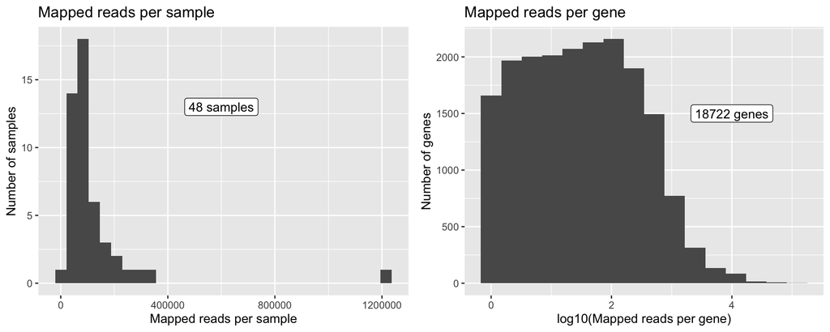

```r
# Number of samples
nsamples <- ncol(counts(dds))

# Number of reads per sample
rps <- qplot(colSums(counts(dds))) +
  labs(x = "Mapped reads per sample", y = "Number of samples",
       title = "Mapped reads per sample") +
  geom_label(aes(x = 6e5, y = 13, label = paste(nsamples, "samples")))
# Sample Mc20-05 has far more counts than others -- may need to rarefy this sample down to median count?

# Number of reads per colony
# count_summ %>%
#   filter(stage == "mapped", colony %in% c(20,22, 26)) %>%
#   group_by(colony) %>%
#   ggplot(aes(x = colony, y = count)) +
#   geom_boxplot() +
#   ylim(0, 300000)

# Number of genes
ngenes <- nrow(counts(dds))
# Number of reads per gene
rpg <- qplot(log10(rowSums(counts(dds))), bins = 16) +
  labs(x = "log10(Mapped reads per gene)", y = "Number of genes",
       title = "Mapped reads per gene") +
  geom_label(aes(x = 4, y = 1500, label = paste(ngenes, "genes")))

countfig <- plot_grid(rps, rpg)

countfig
```

```r
# Save table and fig to include in supplemental information
write_csv(counttable, path = "output/readcounttable.csv")
ggsave(countfig, filename = "figures/FigS3.png", device = "png", width = 150, height = 85, units = "mm")
```

#### Filter and transform count data

```r
# Filter out sample that did not shuffle -- Mc22.12 (17th sample in hs.dds)
hs.dds <- hs.dds[, -17]

######
## testing andrew's suggestion of removing three co-dominant C/D samples: 20-12(3), 26-07(25), 20-01(1))
#hs.dds <- hs.dds[, -c(1,3,25)]

# Remove genes with less than 1 mean count across samples
hs.dds <- hs.dds[ rowMeans(counts(hs.dds)) > 1, ]

# Normalize expression data for visualization purposes using VST tranformation
vsd <- vst(hs.dds, blind = TRUE)
```

# Visualize transcriptome

### Principal Coordinates Analysis

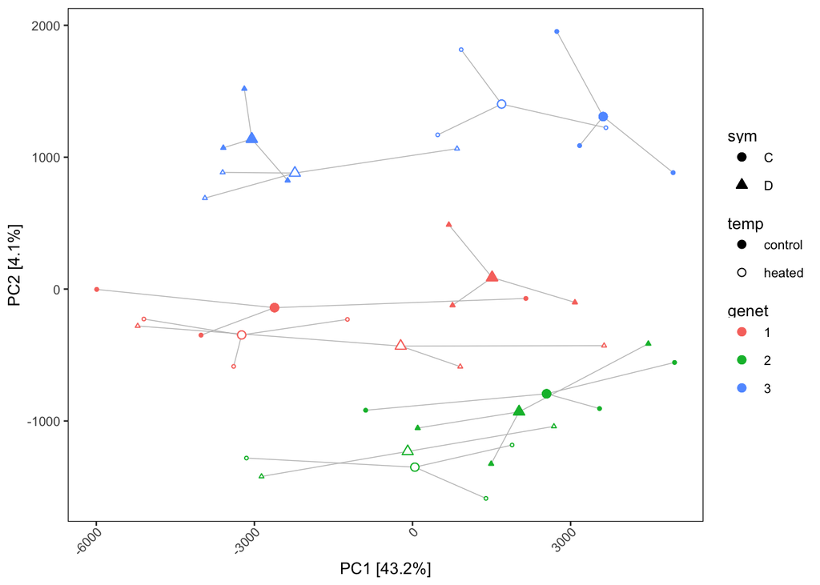

```r
## Calculate distances among samples
sampleDists <- dist(t(assay(vsd)), method = "manhattan")
sampleDistMatrix <- as.matrix(sampleDists)

## Calculate MDS
mds <- as.data.frame(colData(vsd)) %>%
  cbind(cmdscale(sampleDistMatrix)) %>%
  mutate(fillcol = factor(ifelse(trt2 == "h", NA, colony))) %>%    # create factor for fill color in plot
  mutate(genet = case_when(colony == 20 ~ "1", colony == 22 ~ "2", colony == 26 ~ "3")) %>%
  mutate(alphaval = ifelse(trt2 == "h", 1, 0))

# Calculate group centroids for plotting
mds <- mds %>%
  group_by(colony, sym, trt2) %>%
  dplyr::summarise(c1 = mean(`1`), c2 = mean(`2`)) %>%
  full_join(mds)

# Calculate variance explained by each PC
MDS <- cmdscale(sampleDistMatrix, eig = TRUE)
vexpl <- round(MDS$eig*100/sum(MDS$eig),1)[1:2]

# Plot with spiders
pcoa <- ggplot(mds, aes(color = genet, shape = sym)) +
  geom_segment(mapping = aes(x = `1`, y = `2`, xend = c1, yend = c2),
               lwd = 0.25, col = "grey") +
  geom_point(size = 2, aes(x = c1, y = c2, fill = genet, alpha = as.character(alphaval))) +
  geom_point(size = 2, aes(x = c1, y = c2), fill = ifelse(mds$alphaval, "white", NA)) +
  geom_point(size = 0.7, aes(x = `1`, y = `2`, fill = genet, alpha = as.character(alphaval)), show.legend = F) +
  geom_point(size = 0.7, aes(x = `1`, y = `2`), fill = ifelse(mds$alphaval, "white", NA), show.legend = F) +
  scale_shape_manual(values = c(21, 24)) +
  scale_alpha_manual(values = c(1, 0), name = "temp", labels = c("control", "heated")) +
  guides(shape = guide_legend(order = 2, override.aes = list(fill = "black"))) +
  guides(alpha = guide_legend(override.aes = list(shape = 21, alpha = 1, fill = c("black", "white")))) +
  labs(x = paste0("PC1 [", vexpl[1],"%]"), y = paste0("PC2 [", vexpl[2],"%]")) +
  theme_custom() +
  theme(legend.spacing.y = unit(0, "cm"))

pcoa
```

```r
ggsave(filename = "output/pcoa.png", pcoa, width = 109, height = 84.5, units = "mm")
```

### Variance partitioning

Partition total transcriptome variance among explanatory factors (symbiont, heating, and their interaction) for each colony. Based on the PCoA above, it appears that symbiont type should explain the most variance in colony 26, and very little variance in colony 22. Heating should explain more variance in colony 22.

```r
# Get sample data for heat stress experiment into tibble
coldata <- sdat %>%
  rownames_to_column("sample") %>%
  as_tibble() %>%
  select(sample, colony, sym, trt2, date_sampled, group) %>%
  filter(sample != "Mc22.12") #%>%  # Exclude sample that did not shuffle symbionts
  #filter(!sample %in% c("Mc20.12", "Mc26.07", "Mc20-01"))    ### try andrew's suggestion removing codominant samples
# Gather raw counts into tibble
colcounts <- counts %>%
  rownames_to_column("gene") %>%
  as_tibble() %>%
  gather(key = "sample", value = "count", -gene)
# Join count data with sample data, and nest vs count data by colony
all <- left_join(coldata, colcounts) %>%
  filter(colony %in% c(20, 22, 26), date_sampled == "2017-10-28") %>%
  nest(-colony)

# Create DESeqDataSet for each colony, filter genes mean count > 1 within each colony, and vst transform
all <- all %>%
  mutate(sdat = map(data, ~ data.frame(column_to_rownames(distinct(., sample, sym, trt2, group), "sample"))),
         counts = map(data, ~ spread(select(., sample, gene, count), sample, count)),
         counts = map(counts, ~ as.matrix(column_to_rownames(., "gene"))),
         dds = map2(counts, sdat, ~ DESeqDataSetFromMatrix(countData = .x, colData = .y, design = ~ group)),
         ddsf = map(dds, function(x) x[rowMedians(counts(x)) > 1, ]),  # Filter DESeqDataSet
         vsd = map(ddsf, ~ vst(., blind = FALSE)))  # Variance Stabilizing Transformation

# Run variance partition analysis for each colony
cl <- makeCluster(8); registerDoParallel(cl)
all <- all %>%
  mutate(vp = map2(vsd, sdat, ~ fitExtractVarPartModel(
    exprObj = assay(.x), data = .y, formula = ~ (1|sym) + (1|trt2) + (1|sym:trt2)
    )))
stopCluster(cl)

# Calculate sum of variance explained by each source across all genes for each colony
allsumm <- all %>% mutate(vpsum = map(vp, ~ summarise_all(., sum)))

all$vp[[3]] %>%
  as.data.frame(.) %>%
  summarise_all(., median)

plotVarPart(all$vp[[3]])
rowSums(assay(all$vsd[[3]]))
mean(all$vp[[3]]$sym)
weighted.mean(all$vp[[3]]$sym, w = rowSums(assay(all$vsd[[3]])))
```

Plot sources of variance for each colony

```r
varpartfig <- allsumm %>%
  unnest(vpsum, .drop = T) %>%
  gather(source, value, -colony) %>%
  group_by(colony) %>%
  mutate(relvar = value / sum(value)) %>%   # TOTAL VARIANCE NOT SAME FOR EACH COLONY -- NORMALIZE WITHIN COLONY
  filter(source != "Residuals") %>%
  mutate(source = recode(source, trt2 = "temp", `sym:trt2` = "sym:temp")) %>%
  ggplot(aes(x = source, y = relvar*100, fill = colony)) +
  geom_bar(stat = "identity") +
  facet_wrap(~ colony, labeller = global_labeller) +
  labs(x = "", y = "% variance explained") +
  theme_custom() +
  theme(legend.position = "none",
        strip.text.x = element_text(size = 6))

varpartfig

save(varpartfig, file = "output/varpartfig.RData")

ggsave(filename = "output/varpart.png", plot = varpartfig, width = 69, height = 84.5, units = "mm")

fig2 <- cowplot::plot_grid(pcoa, varpartfig, rel_widths = c(2, 1), labels = "AUTO")
ggsave(filename = "figures/fig2.png", fig2, width = 169, height = 84.5, units = "mm")


allsumm %>%
  unnest(vpsum, .drop = T) %>%
  gather(source, value, -colony) %>%
  group_by(colony) %>%
  mutate(relvar = value / sum(value)) %>%   # TOTAL VARIANCE NOT SAME FOR EACH COLONY -- NORMALIZE WITHIN COLONY
  filter(source != "Residuals") %>%
  summarise(total_explained = sum(relvar))
```

[output not shown]

### Discriminant Analysis

Discriminant Analysis of Principal Components (DAPC)

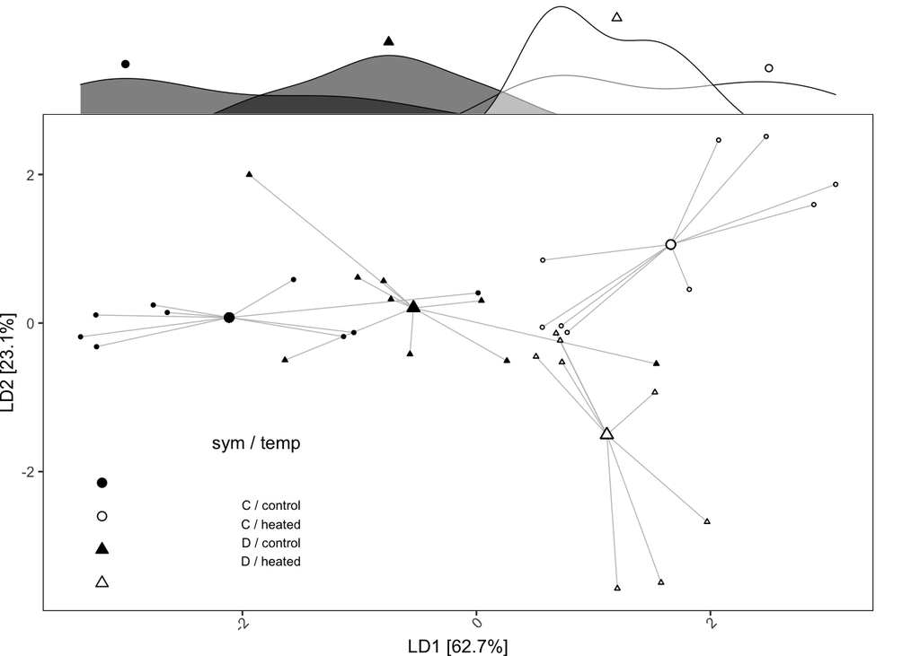

```r
# Discriminant function including all genes
vsd2 <- limma::removeBatchEffect(assay(vsd), vsd$colony)
# use batch-colony-removed vst counts
dat <- data.frame(vsd2)
# use regular vst counts
#dat <- data.frame(assay(vsd))

# How many PCs should be kept?
# dapc2 <- dapc(t(dat), colData(hs.dds)$group, n.da=4, n.pca=35)
# temp <- optim.a.score(dapc2, n.sim = 5)
# my.dapc <- function(n.pca) dapc(t(dat), colData(hs.dds)$group, n.pca = n.pca, n.da = 4)

# library(furrr)
# plan(multiprocess)
# my.dapc.res <- tibble(n.pca = 5:20) %>%
#   mutate(dapc = map(n.pca, my.dapc),
#          a.score = furrr::future_map(dapc, a.score, n.sim = 1000),
#          mean = map_dbl(a.score, ~ .$mean),
#          cumvar = map_dbl(dapc, ~ .$var))
#
# my.dapc.res %>%
#   arrange(-mean) %>%
#   head()

# Retaining 6 PC's gives highest a-score (25%), but only utilizes 44% of variance. Retaining 15 PC's reduces a-score to 17%, but retains 72% of variance. Therefore, let's use 15 PC's for the DA.

dp1 <- dapc(t(dat), colData(hs.dds)$group,
            n.pca = 15, n.da = 2)   # Retain 15 PCs and 2 discriminant functions
#scatter(dp1,bg="white",scree.da=TRUE,scree.pca=TRUE,legend=TRUE,solid=.4)
varexpl <- round((dp1$eig/sum(dp1$eig))[1:2] * 100, 1)

# Axis one represents general heat stress response, and effect of D under control moving toward this transcriptional state.  Axis two represents the *different/unique* heat stress responses of C vs. D corals.

#scatter(dp1, bg = "white", legend = TRUE, scree.da = FALSE)

dapc <- tibble(sample = rownames(dp1$ind.coord),
               grp = dp1$grp,
               LD1 = dp1$ind.coord[,1],
               LD2 = dp1$ind.coord[,2])
dapc <- dapc %>%
  group_by(grp) %>%
  summarize(c1 = mean(LD1),
            c2 = mean(LD2)) %>%
  full_join(dapc)

# Plot with spiders
dapc.fig <-
  ggplot(dapc, aes(shape = factor(grepl("^D", grp)),
                             fill = factor(grepl("h", grp)))) +
  geom_segment(mapping = aes(x = LD1, y = LD2, xend = c1, yend = c2), lwd = 0.25, col = "grey") +
  geom_point(aes(x = c1, y = c2), size = 2) +
  geom_point(aes(x = LD1, y = LD2), size = 0.7, show.legend = FALSE) +
  scale_shape_manual(name = "sym", labels = c("C", "D"), values = c(21, 24)) +
  scale_fill_manual(name = "temp", labels = c("control", "heated"), values = c("black", "white")) +
  guides(fill = guide_legend(override.aes = list(shape = 21, size = 2))) +
  guides(shape = guide_legend(override.aes = list(fill = "black", size = 2))) +
  labs(x = paste0("LD1 [", varexpl[1],"%]"), y = paste0("LD2 [", varexpl[2],"%]")) +
  theme_custom() +
  #theme(legend.position = c(0.25, 0.15)) +
  theme(plot.margin = margin(t = 0, r = 0.9, unit = "cm")) +
  #theme(legend.spacing.y = unit(0, "cm"),
  #      legend.spacing.x = unit(0, "cm")) +
  #theme(legend.box = "horizontal") +
  theme(legend.position = "none") +
  annotate(geom = "text", x = -1.5, y = -1.6, adj = 1, label = "sym / temp", size = 3.5) +
  annotate(geom = "text", x = -1.5, y = -2.825, adj = 1, size = 2.5,
           label = "C / control\nC / heated\nD / control\nD / heated") +
  annotate(geom = "point", x = -3.2, y = seq(from = -2.15, by = -0.45, length.out = 4),
           size = 2, shape = c(21, 21, 24, 24), fill = c("black", "white", "black", "white"))

xplot <-
  ggdensity(dapc, x = "LD1", fill = "grp", lwd = 0.25,
            palette = c("black", "white", "black", "white")) +
  annotate(geom = "point", x = c(-3,-0.75, 1.2, 2.5), y = c(0.37,0.48,0.6,0.35),
           pch = c(21, 24, 24, 21), fill = c("black", "black", "white", "white")) +
  clean_theme() + rremove("legend") +
  theme(plot.margin = unit(c(0, 0, 0, 0), "cm"))

#ggplot(dapc, aes(x = LD1, fill = grp)) + geom_density(alpha = 0.5, adjust = 1)

fig3 <- plot_grid(xplot, NULL, dapc.fig, ncol = 1, align = "hv", rel_heights = c(0.7, -0.28, 2))
fig3
```

```r
ggsave(filename = "figures/fig3.png", plot = fig3, width = 80, height = 80, units = "mm")
```

The DAPC shows that despite the significant variability among colonies, the four treatment groups can be discriminated well based on gene expression data. The first discriminant function (x-axis) represents the effect of heat stress in general, with control temperature corals to the left and heated corals to the right. Along this axis, D-control corals are intermediate between C-control corals and heated corals, showing that the presence of D shifts the transcriptional state toward the heat-stressed state. The second discriminant function (y-axis) separates the distinct responses to heat stress that occur in C vs. D corals.

# Differential expression analysis

Since colonies appear to respond differently to symbiont type and heating, we should analyze differential expression in each colony separately to assess their unique responses. We can also analyze differential expression across all colonies together to see what responses are common to all three.

### Run DESeq

First, within each colony

```r
# Run DESeq pipeline
design(hs.dds) <- formula(~ colony.group)
dsr1 <- DESeq(hs.dds)

# Define group contrasts
group.contrasts <- tibble(num = c("Dh", "Dh", "Dh", "Dc", "Dc", "Ch"),
                          den = c("Dc", "Ch", "Cc", "Ch", "Cc", "Cc"))

# Get DESeq results for all group contrasts for each colony
DE <- crossing(colony = c("20", "22", "26"), group.contrasts) %>%
  mutate(dsr = pmap(list(colony, num, den), function(x, y, z) {
    results(dsr1, contrast = c("colony.group", paste0(x, ".", c(y, z))))}))
```

Then, for all colonies together

```r
# Run DESeq pipeline
design(hs.dds) <- formula(~ colony + group)
dsr2 <- DESeq(hs.dds)

# Get DESeq results for all contrasts and join with results from each colony, from above
DE <- crossing(colony = "all", group.contrasts) %>%
  mutate(dsr = map2(num, den, ~ results(dsr2, contrast = c("group", .x, .y)))) %>%
  bind_rows(DE)
```

### Get significant DEGs

```r
DE <- DE %>%
  mutate(sig = map(dsr, ~ rownames_to_column(data.frame(.[which(.$padj < 0.1), ]), "gene")),
          up = map(sig, ~ filter(., log2FoldChange > 0)),
        down = map(sig, ~ filter(., log2FoldChange < 0)))

# Generate logP values for all differential expression contrasts
DE <- DE %>% mutate(logP = map(dsr, ~ data.frame(
  gene = rownames(data.frame(.)),
  logP = -log10(data.frame(.)$pvalue) * sign(data.frame(.)$log2FoldChange))))

# Count number of differentially expressed genes within each colony, and overall, for each contrast
DEtab <- DE %>%
  filter((num == "Ch" & den == "Cc")|(num == "Dc" & den == "Cc")|
         (num == "Dh" & den == "Ch")|(num == "Dh" & den == "Dc")) %>%
  mutate(nsig = map_dbl( sig, ~ nrow(.)),
          nup = map_dbl(  up, ~ nrow(.)),
          ndn = map_dbl(down, ~ nrow(.)),
          `DEGs [up, down]` = paste0(nsig, " [", nup, ", ", ndn, "]")) %>%
  mutate(genet = case_when(colony == 20 ~ "genet 1", colony == 22 ~ "genet 2", colony == 26 ~ "genet 3",
                           colony == "all" ~ "all genets")) %>%
  mutate(genet = factor(genet, levels = c("genet 1", "genet 2", "genet 3", "all genets"))) %>%
  select(genet, num, den, `DEGs [up, down]`) %>%
  spread(genet, `DEGs [up, down]`)

rownames(DEtab) <- c("C~H~ vs. C~C~", "D~C~ vs. C~C~", "D~H~ vs. C~H~", "D~H~ vs. D~C~")
dek <- DEtab %>% select(3:6) %>%
  knitr::kable(format = "markdown", caption = "Number of differentially expressed genes within individual genets and across all genets for each specified contrast. DEGs identified using DESeq with an adjusted p-value < 0.1. In brackets are the numbers of significantly up- and down-regulated genes.")

dek
```

|  | genet 1 | genet 2 | genet 3 | all genets |
| --- | --- | --- | --- | --- |
| C<sub>H</sub> vs. C<sub>C</sub> | 9 [2, 7] | 28 [12, 16] | 277 [166, 111] | 80 [37, 43] |
| D<sub>C</sub> vs. C<sub>C</sub> | 33 [6, 27] | 58 [22, 36] | 688 [495, 193] | 30 [10, 20] |
| D<sub>H</sub> vs. C<sub>H</sub> | 4 [3, 1] | 9 [5, 4] | 36 [24, 12] | 0 [0, 0] |
| D<sub>H</sub> vs. D<sub>C</sub> | 55 [43, 12] | 35 [21, 14] | 2 [1, 1] | 29 [21, 8] |

```r
#save_kable(dek, file = "output/Table1.html")
```

### DEG Similarities

Similarity of differentially expressed genes across genets and contrasts

##### DEGs in common across genets

```r
# Find genes that are DE in same direction in multiple genets when analyzed individually
DE %>%
  unnest(sig) %>%
  filter(colony != "all") %>%
  group_by(num, den) %>%
  count(gene, log2FoldChange > 0) %>%   # In how many genets is same gene DE in same direction?
  summarise(`1 genet` = sum(n==1), `2 genets` = sum(n==2), `3 genets` = sum(n==3)) %>%
  knitr::kable(caption = "Number of differentially expressed genes in common")  %>%
  kable_styling(full_width = TRUE)
```

Number of differentially expressed genes in common

| num | den | 1 genet | 2 genets | 3 genets |
| --- | --- | --- | --- | --- |
| Ch | Cc | 296 | 9 | 0 |
| Dc | Cc | 767 | 6 | 0 |
| Dc | Ch | 173 | 5 | 0 |
| Dh | Cc | 549 | 5 | 0 |
| Dh | Ch | 43 | 3 | 0 |
| Dh | Dc | 86 | 3 | 0 |

In terms of the specific genes differentially expressed, each colony shows a very different response. There are ZERO differentially expressed genes in common across all three colonies when analyzed individually. However, we still find some differentially expressed genes in common when the colonies are analyzed together, likely due to higher statistical power.

##### DEGs in common beteween heated and shuffled corals

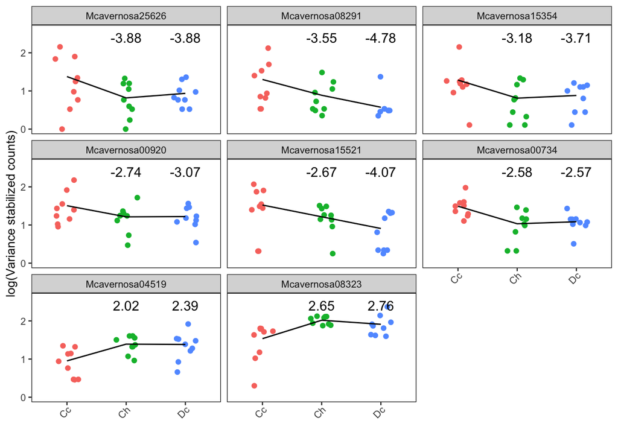

```r
# Find DEGs in common between Ch.Cc and Dc.Cc (same response when heated and when shuffled to D)
genesincommon <- DE %>%
  unite("contrast", num, den, sep = ".") %>%
  filter(colony == "all", contrast %in% c("Ch.Cc", "Dc.Cc")) %>%
  unnest(sig) %>%
  select(contrast, gene, log2FoldChange) %>%
  pivot_wider(names_from = contrast, values_from = log2FoldChange) %>%
  drop_na() %>%
  arrange(Ch.Cc) %>%
  mutate(gene = factor(gene, levels = gene))

# Get normalized counts for the genes in common
gcounts <- data.frame(vsd2[which(rownames(vsd2) %in% genesincommon$gene), ])
gcounts <- rownames_to_column(gcounts, var = "gene") %>%
  pivot_longer(-gene, names_to = "sample", values_to = "count") %>%
  left_join(select(sdat0, sample, group)) %>%
  mutate(gene = factor(gene, levels = levels(genesincommon$gene))) %>%
  filter(group != "Dh")

# Get group log2foldchanges for plotting
gl2fc <- genesincommon %>%
  pivot_longer(-gene, names_to = "group", values_to = "l2fc") %>%
  mutate(group = str_sub(group, 1, 2))
# Get group means for plotting
gcountsmean <- gcounts %>%
  group_by(gene, group) %>%
  summarise(count = mean(count))

# Plot
plotgcounts <- gcounts %>%
  ggplot(aes(x = group, y = pmax(0,log(count)))) +
  geom_jitter(width = 0.2, aes(color = group)) +
  geom_line(data = gcountsmean, aes(group = gene)) +
  geom_text(data = gl2fc, aes(y = 2.4, label = round(l2fc, 2))) +
  facet_wrap(~ gene) +
  theme_custom() +
  theme(legend.position = "none") +
  labs(x = "", y = "log(Variance stabilized counts)") +
  scale_y_continuous(limits = c(0, 2.6))
plotgcounts
```

```r
ggsave(file = "figures/FigS9.png", width = 160, height = 160, units = "mm")

# Table with annotations
# Get gene annotations for plotting
ganno <- left_join(genesincommon, mutate(trinotate, gene = `#gene_id`))
write_tsv(ganno, path = "output/geneanno.tsv")

# Print table
ganno <- ganno %>%
  select(gene, sprot_Top_BLASTP_hit, gene_ontology_blast)

# Replace some  delimiter characters that disrupt HTML parsing
ganno <- mutate_if(ganno, is.character, str_replace_all, pattern = "\\^", replacement = "\\\\")
ganno <- mutate_if(ganno, is.character, str_replace_all, pattern = "\\`", replacement = "||||")

# Print table
knitr::kable(ganno) %>%
  kable_styling("striped") %>%
  column_spec(1:3, width_max = "50em") %>%
  scroll_box(height = "50em", width = "100%")
```

| gene | sprot_Top_BLASTP_hit | gene_ontology_blast |
| --- | --- | --- |
| Mcavernosa25626 | CFA99_HUMAN99_HUMAN:1-244,H:102-348\40.89%ID:5e-44: Full=Cilia- and flagella-associated protein 99 {ECO:0000312\|HGNC:HGNC:51180};; Metazoa; Chordata; Craniata; Vertebrata; Euteleostomi; Mammalia; Eut… | GO:0031514\cellular_component\motile cilium |
| Mcavernosa08291 | SDCG3_BOVIN3_BOVIN:184-316,H:198-352\32.05%ID:2e-11: Full=Serologically defined colon cancer antigen 3 homolog;; Metazoa; Chordata; Craniata; Vertebrata; Euteleostomi; Mammalia; Eutheria; Laurasiather… | GO:0005769\cellular_component\early endosome\|\|\|\|GO:0030496\cellular_component\midbody\|\|\|\|GO:0055037\cellular_component\recycling endosome\|\|\|\|GO:0030904\cellular_component\retromer complex\… |
| Mcavernosa15354 | DSCR3_HUMAN3_HUMAN:81-271,H:96-296\54.19%ID:9e-69: Full=Down syndrome critical region protein 3;; Metazoa; Chordata; Craniata; Vertebrata; Euteleostomi; Mammalia; Eutheria; Euarchontoglires; Primates;… | GO:0005768\cellular_component\endosome\|\|\|\|GO:0005634\cellular_component\nucleus\|\|\|\|GO:0008565\molecular_function\protein transporter activity\|\|\|\|GO:0006886\biological_process\intracellular… |
| Mcavernosa00920 | ACADM_DROME_DROME:4-382,H:1-416\64.03%ID:0: Full=Probable medium-chain specific acyl-CoA dehydrogenase, mitochondrial;; Metazoa; Ecdysozoa; Arthropoda; Hexapoda; Insecta; Pterygota; Neoptera; Holometa… | GO:0005759\cellular_component\mitochondrial matrix\|\|\|\|GO:0005739\cellular_component\mitochondrion\|\|\|\|GO:0003995\molecular_function\acyl-CoA dehydrogenase activity\|\|\|\|GO:0050660\molecular_f… |
| Mcavernosa15521 | PDC6I_XENLA6I_XENLA:1-753,H:1-867\38.3%ID:1e-175: Full=Programmed cell death 6-interacting protein;; Metazoa; Chordata; Craniata; Vertebrata; Euteleostomi; Amphibia; Batrachia; Anura; Pipoidea; Pipida… | GO:0005923\cellular_component\bicellular tight junction\|\|\|\|GO:0005829\cellular_component\cytosol\|\|\|\|GO:0070062\cellular_component\extracellular exosome\|\|\|\|GO:0090543\cellular_component\Fle… |
| Mcavernosa00734 | ACP7_DANRE7_DANRE:4-254,H:177-442\62.78%ID:6e-121: Full=Acid phosphatase type 7 {ECO:0000305};; Metazoa; Chordata; Craniata; Vertebrata; Euteleostomi; Actinopterygii; Neopterygii; Teleostei; Ostarioph… | GO:0005576\cellular_component\extracellular region\|\|\|\|GO:0003993\molecular_function\acid phosphatase activity\|\|\|\|GO:0046872\molecular_function\metal ion binding |
| Mcavernosa04519 | ATP7A_MOUSE7A_MOUSE:539-1033,H:838-1418\48.32%ID:8e-145: Full=Copper-transporting ATPase 1;; Metazoa; Chordata; Craniata; Vertebrata; Euteleostomi; Mammalia; Eutheria; Euarchontoglires; Glires; Rodent… | GO:0016324\cellular_component\apical plasma membrane\|\|\|\|GO:0016323\cellular_component\basolateral plasma membrane\|\|\|\|GO:0031526\cellular_component\brush border membrane\|\|\|\|GO:0031252\cellu… |
| Mcavernosa08323 | PRDX5_HUMAN5_HUMAN:306-456,H:44-214\56.73%ID:2e-59: Full=Peroxiredoxin-5, mitochondrial;; Metazoa; Chordata; Craniata; Vertebrata; Euteleostomi; Mammalia; Eutheria; Euarchontoglires; Primates; Haplorr… | GO:0005737\cellular_component\cytoplasm\|\|\|\|GO:0031410\cellular_component\cytoplasmic vesicle\|\|\|\|GO:0005829\cellular_component\cytosol\|\|\|\|GO:0070062\cellular_component\extracellular exosome… |

These 8 genes are significantly differentially expressed across all colonies in C corals when heated (Ch vs. Cc) and when shuffled to D (Dc vs. Cc).

# GO enrichment analysis

### D<sub>Control</sub> vs. C<sub>Control</sub>

```r
setwd("code/GO_MWU")

# Write all-colony D-control vs. C-control logP values to file for GO_MWU analysis
DE %>%
  filter(colony == "all", num == "Dc", den == "Cc") %>%
  unnest(logP) %>%
  select(gene, logP) %>%
  write.table(., file = "Dctrl.Cctrl.logP.txt", row.names = FALSE, quote = FALSE, sep = ",")

# Run GO_MWU for all-colony D-control vs. C-contol for Biological Process (BP) GO terms
commandArgs <- function(...) c("Dctrl.Cctrl.logP.txt", "BP")
source("GO_MWU.R")

# Run GO_MWU for all-colony D-control vs. C-contol for Molecular Function GO terms
commandArgs <- function(...) c("Dctrl.Cctrl.logP.txt", "MF")
source("GO_MWU.R")

# Run GO_MWU for all-colony D-control vs. C-contol for Cellular Component (CC) GO terms
commandArgs <- function(...) c("Dctrl.Cctrl.logP.txt", "CC")
source("GO_MWU.R")
```

```r
# Get list of all significant GO terms for contrast
Dctrl.Cctrl.GO <- as.list(
  c(BP = "code/GO_MWU/MWU_BP_Dctrl.Cctrl.logP.txt",
    MF = "code/GO_MWU/MWU_MF_Dctrl.Cctrl.logP.txt",
    CC = "code/GO_MWU/MWU_CC_Dctrl.Cctrl.logP.txt")
  ) %>% map(read.table, header = T) %>%
  bind_rows(.id = "ontology") %>%
  as_tibble() %>%
  filter(p.adj < 0.01) %>%
  select(ontology, nseqs, name, delta.rank, p.adj)

# Get list of individual genes with GO annotations and p-values for contrast
allgenepvals <- as.list(
  c(BP = "code/GO_MWU/BP_Dctrl.Cctrl.logP.txt",
    MF = "code/GO_MWU/MF_Dctrl.Cctrl.logP.txt",
    CC = "code/GO_MWU/CC_Dctrl.Cctrl.logP.txt")
  ) %>% map(read_tsv) %>%
  bind_rows(.id = "ontology")

# For all significant GO terms, count how many genes with that GO term have raw pvalue < 0.05 (= "nsig")
Dctrl.Cctrl.GO <- Dctrl.Cctrl.GO %>%
  mutate(nsig = map_dbl(name, function(.) {
    filter(allgenepvals, name == ., -abs(value) <= log10(0.05)) %>%
    nrow(.)
  }))

# Print table
Dctrl.Cctrl.GO %>%
  unite("genes", nsig, nseqs, sep = "/") %>%
  arrange(ontology, delta.rank) %>%
  knitr::kable()
```

| ontology | genes | name | delta.rank | p.adj |
| --- | --- | --- | --- | --- |
| BP | 14/304 | mRNA metabolic process | 254 | 0.0048821 |
| BP | 8/127 | protein localization to membrane | 393 | 0.0035124 |
| BP | 9/105 | RNA catabolic process | 420 | 0.0048821 |
| BP | 9/124 | cellular component disassembly | 428 | 0.0009385 |
| BP | 11/102 | translational elongation | 464 | 0.0010874 |
| BP | 8/99 | protein targeting to membrane | 486 | 0.0007407 |
| BP | 9/92 | translational initiation | 660 | 0.0000004 |
| BP | 7/81 | protein-containing complex disassembly | 670 | 0.0000014 |
| BP | 7/64 | spindle elongation | 696 | 0.0000150 |
| CC | 9/98 | ribosome | 425 | 0.0000463 |
| CC | 9/100 | cytosolic part | 425 | 0.0000463 |
| CC | 7/54 | large ribosomal subunit | 468 | 0.0022966 |
| CC | 8/72 | cytosolic ribosome | 622 | 0.0000001 |
| CC | 2/26 | cytosolic small ribosomal subunit | 677 | 0.0022966 |
| MF | 9/85 | structural constituent of ribosome | 487 | 0.0000155 |

```r
# Run Matz code to create gomwuplot
# setwd("code/GO_MWU/")
# gomwuPlot(inFile = "Dctrl.Cctrl.logP.txt",
#   goDivision = "CC", goAnnotations = "Mcavernosa_gene2go.txt")
```

### C<sub>Heat</sub> vs. C<sub>Ccontrol</sub>

```r
setwd("code/GO_MWU")

# Write all-colony C-heat vs. C-control logP values to file for GO_MWU analysis
DE %>%
  filter(colony == "all", num == "Ch", den == "Cc") %>%
  unnest(logP) %>%
  select(gene, logP) %>%
  write.table(., file = "Cheat.Cctrl.logP.txt", row.names = FALSE, quote = FALSE, sep = ",")

# Run GO_MWU for all-colony C-heat vs. C-contol for Biological Process (BP) GO terms
commandArgs <- function(...) c("Cheat.Cctrl.logP.txt", "BP")
source("GO_MWU.R")

# Run GO_MWU for all-colony C-heat vs. C-contol for Molecular Function GO terms
commandArgs <- function(...) c("Cheat.Cctrl.logP.txt", "MF")
source("GO_MWU.R")

# Run GO_MWU for all-colony C-heat vs. C-contol for Cellular Component (CC) GO terms
commandArgs <- function(...) c("Cheat.Cctrl.logP.txt", "CC")
source("GO_MWU.R")
```

```r
# Get list of all significant GO terms for contrast
Cheat.Cctrl.GO <- as.list(
  c(BP = "code/GO_MWU/MWU_BP_Cheat.Cctrl.logP.txt",
    MF = "code/GO_MWU/MWU_MF_Cheat.Cctrl.logP.txt",
    CC = "code/GO_MWU/MWU_CC_Cheat.Cctrl.logP.txt")
  ) %>% map(read.table, header = T) %>%
  bind_rows(.id = "ontology") %>%
  as_tibble() %>%
  filter(p.adj < 0.01) %>%
  select(ontology, nseqs, name, delta.rank, p.adj)

# Get list of individual genes with GO annotations and p-values for contrast
allgenepvals <- as.list(
  c(BP = "code/GO_MWU/BP_Cheat.Cctrl.logP.txt",
    MF = "code/GO_MWU/MF_Cheat.Cctrl.logP.txt",
    CC = "code/GO_MWU/CC_Cheat.Cctrl.logP.txt")
  ) %>% map(read_tsv) %>%
  bind_rows(.id = "ontology")

# For all significant GO terms, count how many genes with that GO term have raw pvalue < 0.05 (= "nsig")
Cheat.Cctrl.GO <- Cheat.Cctrl.GO %>%
  mutate(nsig = map_dbl(name, function(.) {
    filter(allgenepvals, name == ., -abs(value) <= log10(0.05)) %>%
    nrow(.)
  }))

# Print table
Cheat.Cctrl.GO %>%
  unite("genes", nsig, nseqs, sep = "/") %>%
  arrange(ontology, delta.rank) %>%
  knitr::kable()
```

| ontology | genes | name | delta.rank | p.adj |
| --- | --- | --- | --- | --- |
| BP | 5/33 | ammonium transport | -713 | 0.0094110 |
| BP | 8/43 | sodium ion transport | -622 | 0.0094110 |
| BP | 10/109 | anion transport | -432 | 0.0039258 |
| BP | 17/349 | intracellular signal transduction | 238 | 0.0067086 |
| BP | 14/304 | mRNA metabolic process | 256 | 0.0062611 |
| BP | 25/297 | positive regulation of catalytic activity | 273 | 0.0039045 |
| BP | 19/245 | regulation of transferase activity | 274 | 0.0081854 |
| BP | 8/127 | protein localization to membrane | 440 | 0.0017478 |
| BP | 6/99 | protein targeting to membrane | 475 | 0.0026238 |
| BP | 6/81 | protein-containing complex disassembly | 490 | 0.0045161 |
| CC | 16/291 | ribonucleoprotein complex | 226 | 0.0009429 |
| CC | 5/98 | ribosome | 353 | 0.0024924 |
| CC | 6/100 | cytosolic part | 392 | 0.0004238 |
| CC | 4/72 | cytosolic ribosome | 494 | 0.0001344 |
| MF | 10/53 | secondary active transmembrane transporter activity | -519 | 0.0007211 |
| MF | 8/38 | sodium ion transmembrane transporter activity | -506 | 0.0091040 |
| MF | 9/56 | organic anion transmembrane transporter activity | -442 | 0.0043506 |
| MF | 10/70 | anion transmembrane transporter activity | -427 | 0.0012722 |
| MF | 20/262 | RNA binding | 232 | 0.0012722 |
| MF | 5/85 | structural constituent of ribosome | 422 | 0.0007211 |

### D<sub>Heat</sub> vs. D<sub>Control</sub>

```r
setwd("code/GO_MWU")

# Write all-colony D-heat vs. D-control logP values to file for GO_MWU analysis
DE %>%
  filter(colony == "all", num == "Dh", den == "Dc") %>%
  unnest(logP) %>%
  select(gene, logP) %>%
  write.table(., file = "Dheat.Dctrl.logP.txt", row.names = FALSE, quote = FALSE, sep = ",")

# Run GO_MWU for all-colony D-heat vs. D-contol for Biological Process (BP) GO terms
commandArgs <- function(...) c("Dheat.Dctrl.logP.txt", "BP")
source("GO_MWU.R")

# Run GO_MWU for all-colony D-heat vs. D-contol for Molecular Function GO terms
commandArgs <- function(...) c("Dheat.Dctrl.logP.txt", "MF")
source("GO_MWU.R")

# Run GO_MWU for all-colony D-heat vs. D-contol for Cellular Component (CC) GO terms
commandArgs <- function(...) c("Dheat.Dctrl.logP.txt", "CC")
source("GO_MWU.R")
```

```r
# Get list of all significant GO terms for contrast
Dheat.Dctrl.GO <- as.list(
  c(BP = "code/GO_MWU/MWU_BP_Dheat.Dctrl.logP.txt",
    MF = "code/GO_MWU/MWU_MF_Dheat.Dctrl.logP.txt",
    CC = "code/GO_MWU/MWU_CC_Dheat.Dctrl.logP.txt")
  ) %>% map(read.table, header = T) %>%
  bind_rows(.id = "ontology") %>%
  as_tibble() %>%
  filter(p.adj < 0.01) %>%
  select(ontology, nseqs, name, delta.rank, p.adj)

# Get list of individual genes with GO annotations and p-values for contrast
allgenepvals <- as.list(
  c(BP = "code/GO_MWU/BP_Dheat.Dctrl.logP.txt",
    MF = "code/GO_MWU/MF_Dheat.Dctrl.logP.txt",
    CC = "code/GO_MWU/CC_Dheat.Dctrl.logP.txt")
  ) %>% map(read_tsv) %>%
  bind_rows(.id = "ontology")

# For all significant GO terms, count how many genes with that GO term have raw pvalue < 0.05 (= "nsig")
Dheat.Dctrl.GO <- Dheat.Dctrl.GO %>%
  mutate(nsig = map_dbl(name, function(.) {
    filter(allgenepvals, name == ., -abs(value) <= log10(0.05)) %>%
    nrow(.)
  }))

# Print table
Dheat.Dctrl.GO %>%
  unite("genes", nsig, nseqs, sep = "/") %>%
  arrange(ontology, delta.rank) %>%
  knitr::kable()
```

| ontology | genes | name | delta.rank | p.adj |
| --- | --- | --- | --- | --- |
| BP | 3/92 | translational initiation | -544 | 0.0003707 |
| CC | 2/72 | cytosolic ribosome | -420 | 0.0061805 |
| MF | 3/56 | organic anion transmembrane transporter activity | -472 | 0.0024580 |
| MF | 3/85 | structural constituent of ribosome | -396 | 0.0024580 |
| MF | 3/46 | molecular adaptor activity | 515 | 0.0024580 |
| MF | 2/28 | signaling adaptor activity | 647 | 0.0026139 |

### C<sub>Heat</sub> vs. D<sub>Heat</sub>

```r
setwd("code/GO_MWU")

# Write all-colony D-heat vs. C-heat logP values to file for GO_MWU analysis
DE %>%
  filter(colony == "all", num == "Dh", den == "Ch") %>%
  unnest(logP) %>%
  select(gene, logP) %>%
  write.table(., file = "Dheat.Cheat.logP.txt", row.names = FALSE, quote = FALSE, sep = ",")

# Run GO_MWU for all-colony D-heat vs. C-heat for Biological Process (BP) GO terms
commandArgs <- function(...) c("Dheat.Cheat.logP.txt", "BP")
source("GO_MWU.R")

# Run GO_MWU for all-colony D-heat vs. C-heat for Molecular Function GO terms
commandArgs <- function(...) c("Dheat.Cheat.logP.txt", "MF")
source("GO_MWU.R")

# Run GO_MWU for all-colony D-heat vs. C-heat for Cellular Component (CC) GO terms
commandArgs <- function(...) c("Dheat.Cheat.logP.txt", "CC")
source("GO_MWU.R")
```

```r
Dheat.Cheat.GO <- as.list(
  c(BP = "code/GO_MWU/MWU_BP_Dheat.Cheat.logP.txt",
    MF = "code/GO_MWU/MWU_MF_Dheat.Cheat.logP.txt",
    CC = "code/GO_MWU/MWU_CC_Dheat.Cheat.logP.txt")
  ) %>% map(read.table, header = T) %>%
  bind_rows(.id = "ontology") %>%
  as_tibble() %>%
  filter(p.adj < 0.01)

### no significant GO terms for Dheat vs. Cheat...
```

Supplemental table with all GO results

```r
allGO <- bind_rows(.id = "contrast",
  Dctrl.Cctrl = Dctrl.Cctrl.GO,
  Cheat.Cctrl = Cheat.Cctrl.GO,
  Dheat.Dctrl = Dheat.Dctrl.GO,
  Dheat.Cheat = Dheat.Cheat.GO
) %>%
  unite("genes", nsig, nseqs, sep = "/") %>%
  select(contrast, ontology, genes, name, delta.rank, p.adj) %>%
  arrange(contrast, ontology, delta.rank)

write_csv(allGO, path = "output/allGO.csv")
```

# KOG enrichment analysis

Using the signed log(p-values) from the differential expression analysis, we can analyze which KOG classifications are up- or down-regulated within each colony, and across all three colonies together.

```r
# Import KOG annotations for Mcavernosa genome # Downloaded from M. Studivan github
gene2kog <- read.table("data/genome/Mcavernosa_iso2kog.tab", sep = "\t") %>%
   filter(!V2 == "")

# Run KOG.MWU analysis on all contrasts
KOG <- DE %>%
  mutate(KOG = map(logP, ~ kog.mwu(., gene2kog)),
         # If a KOG term has <10 genes associated with it, set delta rank to zero
         KOG = map(KOG, ~ mutate(., delta.rank = ifelse(nseqs < 10, 0, delta.rank))))

# Generate all KOG delta rank tables
kogtables <- KOG %>%
  mutate(genet = case_when(colony == 20 ~ "genet 1",
                           colony == 22 ~ "genet 2",
                           colony == 26 ~ "genet 3",
                           colony == "all" ~ "all genets")) %>%
  mutate(genet = factor(genet, levels = c("genet 1", "genet 2", "genet 3", "all genets"))) %>%
  unnest(KOG) %>%
  select(genet, num, den, term, delta.rank) %>%
  split(list(.$num, .$den), drop = TRUE) %>%
  map(~ spread(., genet, delta.rank)) %>%
  map(~ column_to_rownames(select(., -num, -den), "term"))

# Generate KOG p-value stars
kogpvals <- KOG %>%
  mutate(genet = case_when(colony == 20 ~ "genet 1",
                           colony == 22 ~ "genet 2",
                           colony == 26 ~ "genet 3",
                           colony == "all" ~ "all genets")) %>%
  mutate(genet = factor(genet, levels = c("genet 1", "genet 2", "genet 3", "all genets"))) %>%
  unnest(KOG) %>%
  select(genet, num, den, term, padj) %>%
  split(list(.$num, .$den), drop = TRUE) %>%
  map(~ spread(., genet, padj)) %>%
  map(~ column_to_rownames(select(., -num, -den), "term")) %>%
  map(~ transmute_all(., gtools::stars.pval))
```

### KOG results for each genet

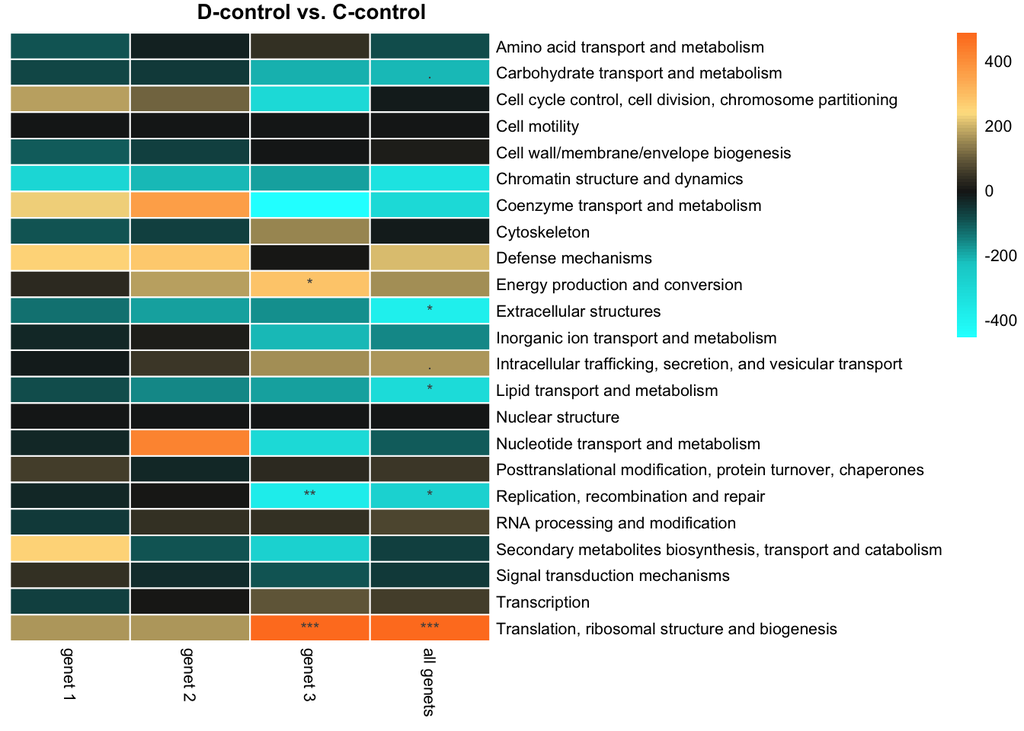

```r
# Function to plot KOG delta ranks heatmap
KOGheatmap <- function(deltaranks, pvals, ...) {
  deltaranks <- as.matrix(deltaranks)
  paletteLength <- 100
  myColor <- colorRampPalette(rev(c("chocolate1","#FEE090","grey10", "cyan3","cyan")))(paletteLength)
  myBreaks <- c(seq(min(deltaranks), 0, length.out = ceiling(paletteLength/2) + 1),
                seq(max(deltaranks)/paletteLength, max(deltaranks),
                    length.out = floor(paletteLength/2)))
  pheatmap(mat = deltaranks, display_numbers = pvals, fontsize_number = 8,
           cluster_cols = FALSE, cluster_rows = FALSE,
           treeheight_row = 15, treeheight_col = 15,
           border_color = "white", scale = "none",
           color = myColor, breaks = myBreaks, ...)
}

KOGDcCc <- KOGheatmap(kogtables$Dc.Cc, kogpvals$Dc.Cc, main = "                     D-control vs. C-control",
                      fontsize = 8)
```

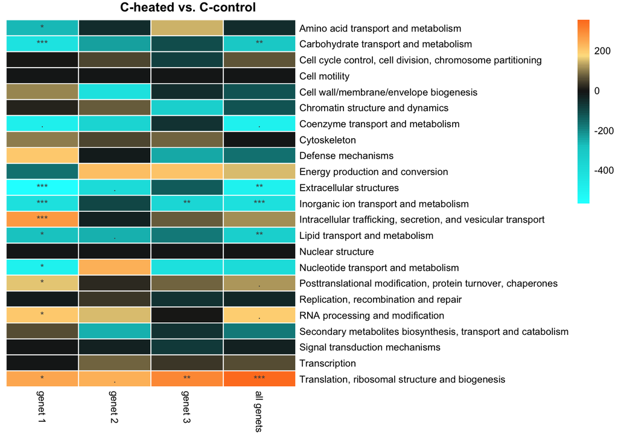

```r
ggsave(filename = "figures/FigS5.png", plot = KOGDcCc, width = 112, height = 84.5, units = "mm")
KOGChCc <- KOGheatmap(kogtables$Ch.Cc, kogpvals$Ch.Cc, main = "                     C-heated vs. C-control",
                      fontsize = 8)
```

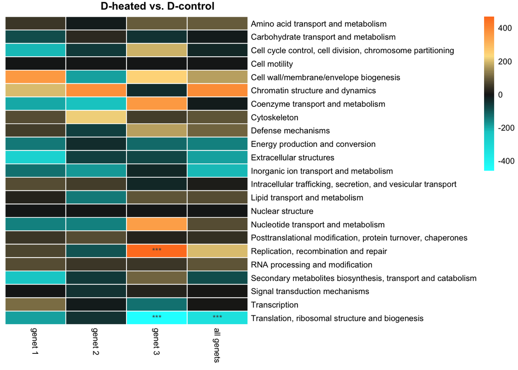

```r
ggsave(filename = "figures/FigS6.png", plot = KOGChCc, width = 112, height = 84.5, units = "mm")
KOGDhDc <- KOGheatmap(kogtables$Dh.Dc, kogpvals$Dh.Dc, main = "                     D-heated vs. D-control",
                      fontsize = 8)
```

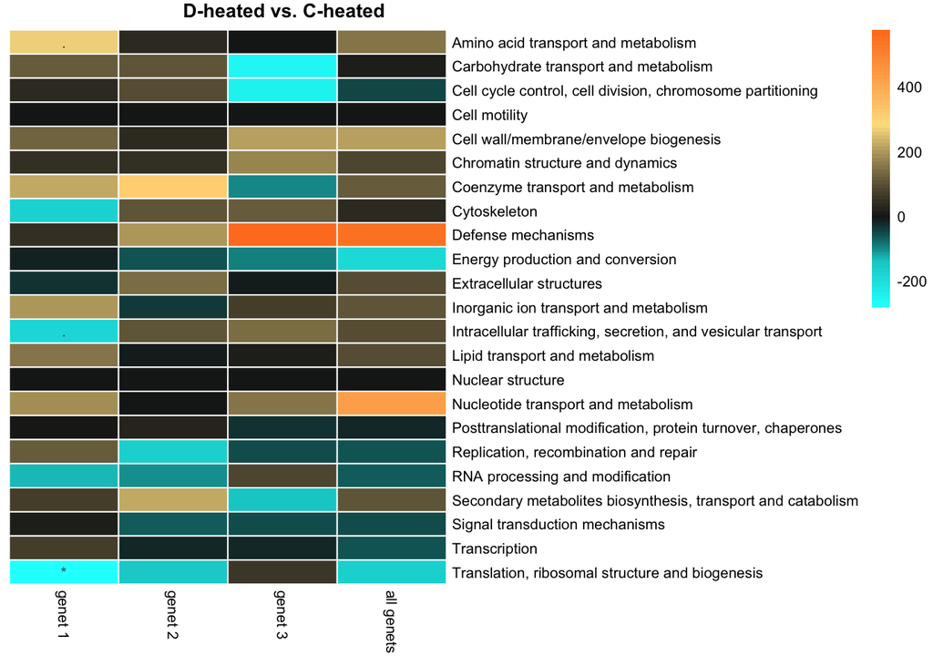

```r
ggsave(filename = "figures/FigS7.png", plot = KOGDhDc, width = 112, height = 84.5, units = "mm")
KOGDhCh <- KOGheatmap(kogtables$Dh.Ch, kogpvals$Dh.Ch, main = "                     D-heated vs. C-heated",
                      fontsize = 8)
```

```r
ggsave(filename = "figures/FigS8.png", plot = KOGDhCh, width = 112, height = 84.5, units = "mm")
```

### KOG results across all genets

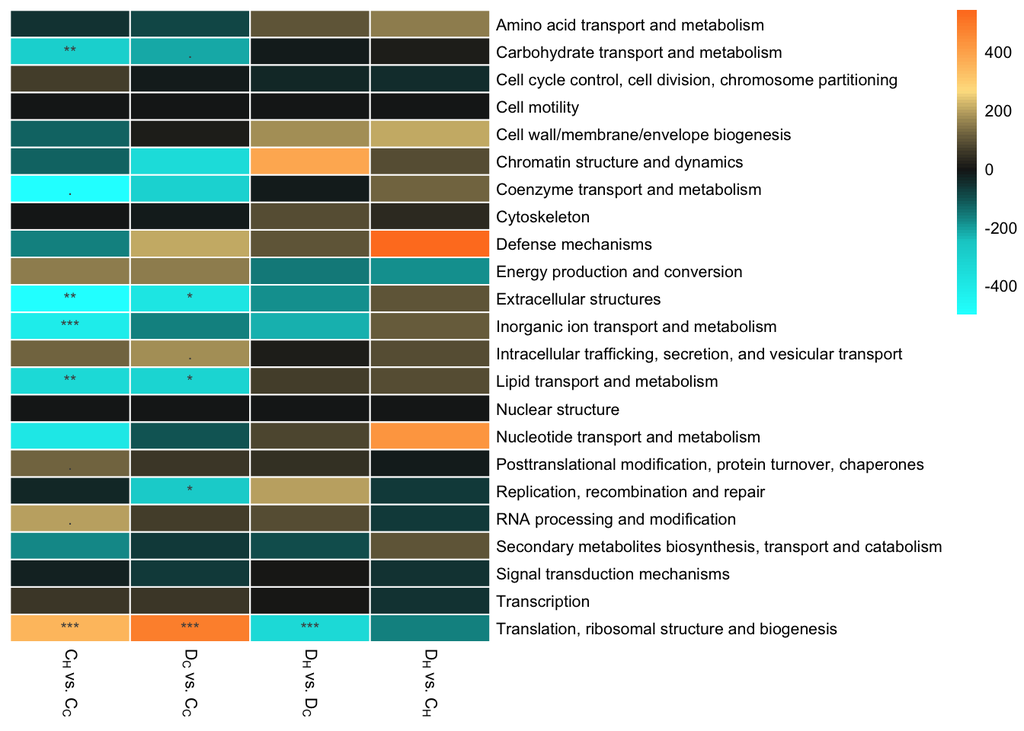

```r
kogtable2 <- KOG %>%
  unnest(KOG) %>%
  filter(colony == "all") %>%
  select(num, den, term, delta.rank) %>%
  unite("contrast", num, den, sep = ".") %>%
  spread(contrast, delta.rank) %>%
  select(term, Ch.Cc, Dc.Cc, Dh.Dc, Dh.Ch) %>%
  column_to_rownames("term")

kogpval2 <- KOG %>%
  unnest(KOG) %>%
  filter(colony == "all") %>%
  select(num, den, term, padj) %>%
  unite("contrast", num, den, sep = ".") %>%
  spread(contrast, padj) %>%
  select(term, Ch.Cc, Dc.Cc, Dh.Dc, Dh.Ch) %>%
  column_to_rownames("term") %>%
  transmute_all(gtools::stars.pval)

fig4a <- KOGheatmap(
  select(kogtable2, Ch.Cc, Dc.Cc, Dh.Dc, Dh.Ch),
  select( kogpval2, Ch.Cc, Dc.Cc, Dh.Dc, Dh.Ch),
  labels_col = c(expression("C"[H]~"vs."~"C"[C]),
                  expression("D"[C]~"vs."~"C"[C]),
                  expression("D"[H]~"vs."~"D"[C]),
                  expression("D"[H]~"vs."~"C"[H])),
  fontsize = 8)
```

```r
ggsave(filename = "figures/fig4a.png", fig4a, width = 112, height = 84.5, units = "mm")
```

### Count DEGs for each KOG

```r
# Get number of genes DE (unadjusted p<0.05) associated with each KOG term (this is default behavior of KOG_MWU in its plotting function)
kogout <- KOG %>%
  unnest(KOG) %>%
  filter(colony == "all") %>%
  unite("contrast", num, den, sep = ".") %>%
  select(contrast, dsr, term, nseqs, delta.rank, padj) %>%
  filter(contrast %in% c("Ch.Cc", "Dh.Dc", "Dc.Cc", "Dh.Ch"))

kogout <- kogout %>%
  mutate(nsig = map2_dbl(term, dsr, function(.x, .y) {
    geneswithterm <- dplyr::filter(gene2kog, V2 == as.character(.x)) %>% pull(V1)
    geneswithp <- rownames_to_column(data.frame(.y[which(.y$pvalue < 0.05), ]), "gene")
    return(length(intersect(geneswithterm, geneswithp$gene)))
  }))

# Write table for supp info
kogout <- kogout %>%
  filter(padj < 0.1) %>%
  unite("genes", nsig, nseqs, sep = "/") %>%
  select(contrast, genes, term, delta.rank, padj) %>%
  mutate(padj = signif(padj, digits = 3))

write_tsv(kogout, "output/kogout.txt")

knitr::kable(kogout)  %>%
  kable_styling(full_width = TRUE)
```

| contrast | genes | term | delta.rank | padj |
| --- | --- | --- | --- | --- |
| Dh.Dc | 8/231 | Translation, ribosomal structure and biogenesis | -336 | 0.000642 |
| Dc.Cc | 17/231 | Translation, ribosomal structure and biogenesis | 486 | 0.000000 |
| Dc.Cc | 10/140 | Lipid transport and metabolism | -313 | 0.024100 |
| Dc.Cc | 5/72 | Extracellular structures | -387 | 0.040500 |
| Dc.Cc | 4/140 | Replication, recombination and repair | -274 | 0.040500 |
| Dc.Cc | 22/326 | Intracellular trafficking, secretion, and vesicular transport | 171 | 0.057400 |
| Dc.Cc | 10/154 | Carbohydrate transport and metabolism | -217 | 0.099100 |
| Ch.Cc | 12/231 | Translation, ribosomal structure and biogenesis | 355 | 0.000215 |
| Ch.Cc | 13/144 | Inorganic ion transport and metabolism | -412 | 0.000466 |
| Ch.Cc | 6/72 | Extracellular structures | -499 | 0.002990 |
| Ch.Cc | 12/140 | Lipid transport and metabolism | -332 | 0.006440 |
| Ch.Cc | 6/154 | Carbohydrate transport and metabolism | -299 | 0.009690 |
| Ch.Cc | 14/238 | RNA processing and modification | 192 | 0.057100 |
| Ch.Cc | 44/609 | Posttranslational modification, protein turnover, chaperones | 123 | 0.060100 |
| Ch.Cc | 6/30 | Coenzyme transport and metabolism | -497 | 0.062700 |

### Correlation of KOG delta-ranks

Testing similarity of transcriptome responses

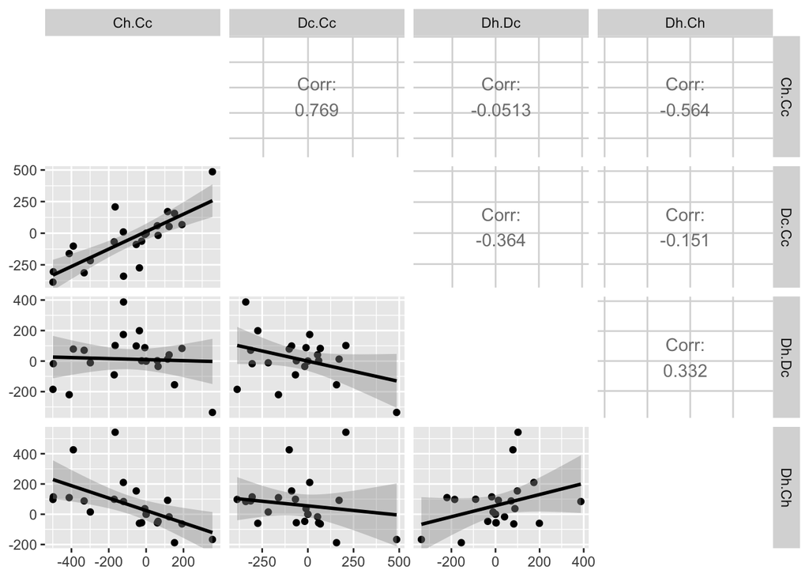

```r
# Visualize KOG response correlations between different contrasts
GGally::ggpairs(kogtable2, lower = list(continuous = "smooth"), diag = NULL)
```

```r
# Test whether correlation coefficients are greater than 0.5 (null hypothesis when comparing ratios with common denominator) or 0 (when ratios contain all different variables)
comparisons <- c("~ Ch.Cc + Dc.Cc", "~ Ch.Cc + Dc.Ch", "~ Ch.Cc + Dh.Cc", "~ Ch.Cc + Dh.Ch", "~ Ch.Cc + Dh.Dc",
                 "~ Dc.Cc + Dc.Ch", "~ Dc.Cc + Dh.Cc", "~ Dc.Cc + Dh.Ch", "~ Dc.Cc + Dh.Dc",
                 "~ Dc.Ch + Dh.Cc", "~ Dc.Ch + Dh.Ch", "~ Dc.Ch + Dh.Dc",
                 "~ Dh.Cc + Dh.Ch", "~ Dh.Cc + Dh.Dc",
                 "~ Dh.Ch + Dh.Dc")

tibble(comparison = comparisons) %>%
  filter(!grepl("Dc.Ch|Cc.Dh|Dh.Cc", comparison)) %>%
  mutate(cor = map(comparison, ~ cor.test(as.formula(.), data = kogtable2) %>% broom::tidy())) %>%
  unnest() %>%
  select(comparison, estimate, conf.low, conf.high) %>%
  mutate(samevars = map_lgl(comparison, ~ any(table(str_extract_all(., "C.|D.")) > 1)),
         nocor = pmap_lgl(list(samevars, conf.low, conf.high), function(x, y, z) {
           ifelse(x, !(y > 0.5 | z < -0.5), between(0, y, z))}))
```

```
## # A tibble: 6 x 6
##   comparison      estimate conf.low conf.high samevars nocor
##   <chr>              <dbl>    <dbl>     <dbl> <lgl>    <lgl>
## 1 ~ Ch.Cc + Dc.Cc   0.769    0.522     0.897  TRUE     FALSE
## 2 ~ Ch.Cc + Dh.Ch  -0.564   -0.792    -0.198  TRUE     TRUE
## 3 ~ Ch.Cc + Dh.Dc  -0.0513  -0.454     0.369  FALSE    TRUE
## 4 ~ Dc.Cc + Dh.Ch  -0.151   -0.530     0.279  FALSE    TRUE
## 5 ~ Dc.Cc + Dh.Dc  -0.364   -0.675     0.0572 TRUE     TRUE
## 6 ~ Dh.Ch + Dh.Dc   0.332   -0.0932    0.654  TRUE     TRUE
```

```r
# The 95% correlation coefficient for Ch.Cc and Dc.Cc does not contain 0.5 -- the expected correlation coefficient between the two ratios if the correlation between their numerators was zero.

# The correlation between Dc/Cc and Ch/Cc is 0.77. They have a common denominator so part of this correlation is due to that alone, although part is also due to an (unmeasurable) correlation between Dc and Ch. The correlation between Dc and Ch must be at least 0.5 (in the most conservative case that the correlation of both Dc and Ch with Cc is zero) (see Dunlap et al. 1997). Further evidence that Dc and Ch are correlated is that no KOG categories are significantly different in the comparison of Dc to Ch.
```

```r
# Figure showing KOG correlations between Dc.Cc and Ch.Cc, and lack of correlation between Dh.Dc and Ch.Cc.
fig4b <- kogtable2 %>%
  rownames_to_column("kog") %>%
  gather(contrast, value, -kog, -Ch.Cc) %>%
  filter(contrast %in% c("Dh.Dc", "Dc.Cc")) %>%
  mutate(contrast = factor(contrast, levels = c("Dh.Dc", "Dc.Cc"),
                           labels = c(expression("D"[H]~"vs."~"D"[C]), expression("D"[C]~"vs."~"C"[C])))) %>%
  ggplot(aes(x = Ch.Cc, y = value)) +
  facet_grid(contrast ~ ., labeller = "label_parsed") +
  geom_point() +
  geom_smooth(method = "lm") +
  stat_cor(aes(label = ..r.label..), size = 2) +
  theme_custom() +
  labs(x = expression("C"[H]~"vs."~"C"[C]~"KOG delta ranks"), y = "KOG delta ranks")

ggsave(plot = last_plot(), filename = "figures/fig4b.png", width = 80, height = 120, units = "mm")
```

```r
# Combine KOG heatmap with KOG correlations into multi-panel figure
grob4a = grid::grid.grabExpr(grid::grid.draw(fig4a))

fig4 <- plot_grid(NULL, grob4a, fig4b, rel_widths = c(0.025, 0.685, 0.29),
                  nrow = 1, labels = c("A", "", "B"))

ggsave(plot = fig4, filename = "figures/fig4.png", width = 169, height = 90, units = "mm")
```

# No-shuffling controls

Are DEGs associated with symbiont shuffling due to having changed symbionts, or having bleached?

Other coral genotypes were bleached but did not shuffle their symbionts – they had clade C to begin with, and clade C after recovery. We can use these samples as controls to test whether the change in gene expression in corals that shuffle is attributable to the symbiont change or the previous stress.

```r
# Colonies EXCEPT 20, 22, and 26
# Only time point at end of heat stress (but these were all at ambient - no hs)
ns.dds <- dds[, !colData(dds)$colony %in% c(20, 22, 26) & colData(dds)$date_sampled == "2017-10-28"]
# Filter out Mc2840 -- it shuffled and had high propD
ns.dds <- ns.dds[, !rownames(colData(ns.dds)) %in% c("Mc28.40")]
### Remove genes counted zero times in subset
ns.dds <- ns.dds[ rowSums(counts(ns.dds)) > 0, ]
# Remove genes with less than 1 mean count across samples
ns.dds <- ns.dds[ rowMeans(counts(ns.dds)) > 1, ]
### Drop unused factor levels
colData(ns.dds) <- droplevels(colData(ns.dds))
# Add design formula
design(ns.dds) <- formula(~ colony + trt1)

# Run DESeq pipeline
ns.dds <- DESeq(ns.dds)

# Find DE genes between prev. bleached vs. control (trt1)
res <- results(ns.dds, contrast = c("trt1", "b", "c"))
summary(res)  ### No differentially expressed genes
```

```
##
## out of 9220 with nonzero total read count
## adjusted p-value < 0.1
## LFC > 0 (up)       : 0, 0%
## LFC < 0 (down)     : 0, 0%
## outliers [1]       : 0, 0%
## low counts [2]     : 0, 0%
## (mean count < 0)
## [1] see 'cooksCutoff' argument of ?results
## [2] see 'independentFiltering' argument of ?results
```

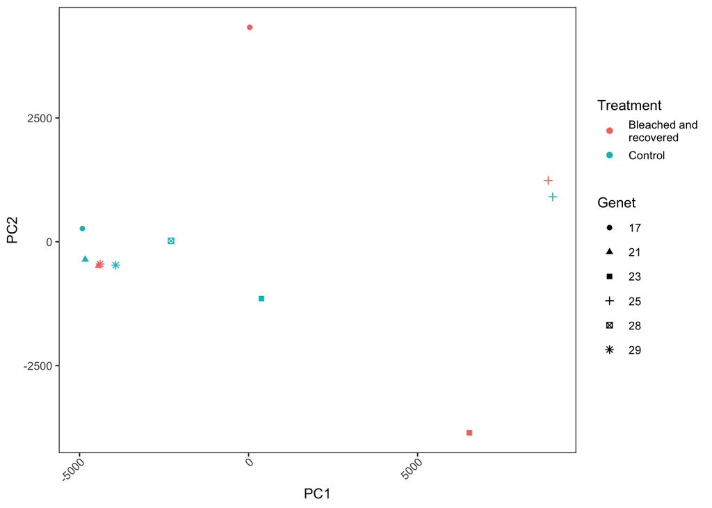

```r
# Visualize nonshuffling corals with PCoA
vsd <- vst(ns.dds, blind = TRUE)

## Calculate distances among samples
sampleDists <- dist(t(assay(vsd)), method = "manhattan")
sampleDistMatrix <- as.matrix(sampleDists)

## Calculate MDS
mds <- as.data.frame(colData(vsd)) %>%
  cbind(cmdscale(sampleDistMatrix))# %>%

noshuffpcoa <- ggplot(mds, aes(x = `1`, y = `2`, color = trt1, shape = colony)) +
  geom_point() +
  scale_color_discrete(name = "Treatment", labels = c("Bleached and\nrecovered", "Control")) +
  scale_shape_discrete(name = "Genet") +
  labs(x = "PC1", y = "PC2") +
  theme_custom()
noshuffpcoa
```

```r
ggsave(noshuffpcoa, file = "figures/FigS4.png", width = 120, height = 90, units = "mm")
```